# R Notebook

```r
library(tidyverse)
```

## 8.1

Recreate the simulated data from Exercise 7.2:

```r
library(mlbench)
set.seed(200)
simulated <- mlbench.friedman1(200, sd = 1)
simulated <- cbind(simulated$x, simulated$y)
simulated <- as.data.frame(simulated)
colnames(simulated)[ncol(simulated)] <- "y"
```

1. Fit a random forest model to all of the predictors, then estimate the variable importance

```r
library(randomForest)
library(caret)
model1 <- randomForest(y ~., data = simulated, importance = TRUE,
                       ntree = 1000)
rfImp <- varImp(model1, scale = FALSE)
rfImp
```

|  | Overall |
| --- | --- |
| V1 | 8.66496174 |
| V2 | 6.36504194 |
| V3 | 0.76724347 |
| V4 | 7.93742254 |
| V5 | 2.10190958 |
| V6 | 0.19154480 |
| V7 | 0.04177869 |
| V8 | -0.08293296 |
| V9 | -0.06267951 |
| V10 | -0.04521494 |

Does the random forest model significantly use the uninformative predictors (V6-V10).

```r
simulated$duplicate1 <- simulated$V1 + rnorm(200) * .1
cor(simulated$duplicate1, simulated$V1)
```

```
[1] 0.9386619
```

Fit another random forest model to these data. Did the importance score for V1 change? What happens when you add another predictor that is also highly correlated with V1?

```r
model1 <- randomForest(y ~., data = simulated, importance = TRUE,
                       ntree = 1000)
rfImp <- varImp(model1, scale = FALSE)
```

```r
library(data.table)
dt <- setDT(varImp(model1, scale = FALSE), keep.rownames = TRUE)[]
options(scipen=99)
dt[order(-Overall)]
```

| rn | Overall |
| --- | --- |
| V4 | 6.59026253 |
| V2 | 6.04782043 |
| V1 | 5.34138782 |
| duplicate1 | 4.71267815 |
| V5 | 1.86532068 |
| V3 | 0.54776459 |
| V6 | 0.13680850 |
| V9 | 0.06233358 |
| V10 | 0.05506748 |
| V7 | 0.04745508 |

[output cut: 1 more lines]

> We do see that the importance score has been reduced with the duplicate variable. The interaction between the two variables is reducing the signal we receive from using simple one of the variables.

```r
simulated$duplicate2 <- simulated$V1 + rnorm(200) * .15
cor(simulated$duplicate2, simulated$V1)
```

```
[1] 0.8849327
```

```r
model2 <- randomForest(y ~., data = simulated, importance = TRUE,
                       ntree = 1000)
rfImp <- varImp(model2, scale = FALSE)
```

```r
library(data.table)
dt <- setDT(varImp(model2, scale = FALSE), keep.rownames = TRUE)[]
options(scipen=99)
dt[order(-Overall)]
```

| rn | Overall |
| --- | --- |
| V4 | 7.292570850 |
| V2 | 6.562165756 |
| V1 | 4.562573722 |
| duplicate1 | 4.295437598 |
| V5 | 2.070957251 |
| duplicate2 | 1.384370802 |
| V3 | 0.517422886 |
| V6 | 0.132806443 |
| V7 | 0.072280073 |
| V9 | -0.003797135 |

[output cut: 2 more lines]

```r
library(party)
fit.cforest <- cforest(y ~., data = simulated)
```

```r
library(data.table)
dt <- setDT(party::varimp(fit.cforest, conditional = TRUE) %>% data.frame(), keep.rownames = TRUE)[]
options(scipen=99)
dt[order(-.)]
```

| rn | . |
| --- | --- |
| V4 | 5.281196888 |
| V2 | 4.373678395 |
| duplicate1 | 1.719885895 |
| V1 | 1.288320322 |
| V5 | 0.971063628 |
| duplicate2 | 0.276946982 |
| V3 | 0.021087453 |
| V6 | 0.019535747 |
| V7 | 0.011797289 |
| V10 | 0.002561214 |

[output cut: 2 more lines]

```r
dt <- setDT(party::varimp(fit.cforest, conditional = FALSE) %>% data.frame(), keep.rownames = TRUE)[]
options(scipen=99)
dt[order(-.)]
```

| rn | . |
| --- | --- |
| V4 | 6.57619578 |
| V2 | 5.79417540 |
| duplicate1 | 4.99198355 |
| V1 | 3.74038496 |
| V5 | 1.62301336 |
| duplicate2 | 1.02429697 |
| V7 | 0.04711682 |
| V9 | 0.02985211 |
| V6 | 0.01570609 |
| V3 | 0.01140049 |

[output cut: 2 more lines]

> The top few variables remain at the same level of importance for both models. However, the variable importance is less using conditional inference trees via cpart from the party package.
4. Repeat this process with different tree models, such as boosted trees and Cubist. Does the same pattern occur?

```r
library(Cubist)
fit.cubist <- cubist(simulated %>% select(-y), simulated$y, committees = 4)
fit.cubist
```

```
Call:
cubist.default(x = simulated %>% select(-y), y = simulated$y, committees = 4)

Number of samples: 200
Number of predictors: 12

Number of committees: 4
Number of rules per committee: 1, 4, 2, 5
```

```r
dt <- setDT(varImp(fit.cubist) %>% data.frame(), keep.rownames = TRUE)[]
options(scipen=99)
dt[order(-Overall)]
```

| rn | Overall |
| --- | --- |
| V2 | 64.0 |
| V1 | 63.5 |
| V4 | 50.0 |
| V5 | 49.0 |
| V3 | 35.0 |
| duplicate1 | 25.5 |
| duplicate2 | 7.5 |
| V6 | 4.0 |
| V7 | 0.0 |
| V8 | 0.0 |

[output cut: 2 more lines]

> Using the cubist model we actually get very different results. In fact, the model appears to adjust for the highly correlated variables and gives us variable importance that more closely match our original data set before the added variables.

## 8.2

Use a simulation to show tree bias with different granularity.

```r
as.factor(round(data.set$TwoFactor1, 0))
```

```
  [1] -1 -1 0  2  0  -3 0  0  0  -1 1  0  0  1  -1 -3 1  -3 1  2  1  -1 -2 2  -1 1  0  2  -2 -1 -2 -3 -2 3  1  2  2
 [38] 1  -1 0  -4 3  2  1  -1 3  1  1  2  1  -1 1  -2 3  1  -1 -1 2  0  1  -1 0  -1 0  -2 1  -4 -1 0  1  0  1  -1 0
 [75] 2  2  4  2  -1 -1 2  4  -1 1  -2 2  -2 -1 -1 0  0  -1 1  -2 -1 0  -2 3  1  -2 0  0  -2 0  -2 1  1  0  -1 1  2
[112] 2  3  0  -1 0  -1 -1 -3 0  1  1  -1 2  0  0  -2 -2 1  -1 -1 0  -4 1  0  1  2  0  0  2  -1 1  1  0  0  3  2  0
[149] 1  2  -1 -1 -1 2  1  0  0  -4 -2 2  1  2  0  1  1  3  1  0  1  1  1  1  1  1  0  2  -1 -1 -2 1  2  -1 1  -2 -2
[186] 1  0  -1 2  -1 1  2  -3 -1 1  2  2  4  -2 0  0  1  0  1  -2 0  -2 -1 -1 1  0  3  -1 -3 -1 3  -2 0  0  -2 1  -1
[223] 1  0  1  -1 -1 1  -3 0  0  2  0  -1 -1 -1 -2 2  2  0  1  -1 2  2  1  3  -1 1  1  0  -2 1  0  0  1  -2 0  1  -2
[260] -2 2  -4 -2 0  0  -1 1  1  3  0  -2 0  -1 0  0  1  1  -1 0  1  -2 -2 1  0  -1 -4 3  1  -2 -1 -1 0  -2 2  3  1
[297] 0  -1 0  -2
Levels: -4 -3 -2 -1 0 1 2 3 4
```

[figure not shown]

```r
library(data.table)
dt <- setDT(varImp(r.fit), keep.rownames = TRUE)[]
options(scipen=99)
dt[order(-Overall)]
```

| rn | Overall |
| --- | --- |
| TwoFactor2 | 1.93786164 |
| Linear06 | 1.28454558 |
| Linear02 | 1.05931767 |
| Noise1 | 0.99590860 |
| Linear10 | 0.95311391 |
| Linear09 | 0.91457379 |
| Corr6 | 0.82566631 |
| Noise6 | 0.81724533 |
| Linear04 | 0.75341212 |
| Noise2 | 0.73235876 |

[output cut: 19 more lines]

## 8.3

> A learning rate closer to 1 will make less corrections for each tree added to the model. A high bagging fraction closer to 1 indicates more of the data is used which can lead to overfitting. So as the learning rate and bagging fraction increase, the importance will be placed on fewer and fewer predictors.
2. Which model do you think would be more predictive of other samples?

> Subsequently, if the parameters increase the model performance will then decrease. Therefore, the model on the left will perform better. Although, I would be cautious about usefulness. If a model uses variables that can’t always be reliably captured than a model dependent on very few variables may be more powerful.
3. How would increasing interaction depth affect the slope of predictor importance for either model in Fig. 8.24?

> Interaction depth specifies the tree depth and node splits. As the tree depth increase, and more node splits occur the variable importance becomes spread across more predictors. In both models the variable importance would decrease for the top variables and increase for less important variables. If we have any highly correlated variables we may actually see a swap of importance between the two variables.

## 8.7

Refer to Exercise 6.3 and 7.5 which describe a chemical manufacturing process. Use the same data imputation, data splitting, and pre-processing steps as before and train several tree-based models:

```r
library(missForest)
library(AppliedPredictiveModeling)
library(doParallel)
data("ChemicalManufacturingProcess")
set.seed(1234)
registerDoParallel(cores=3)
chem.imput <- missForest(ChemicalManufacturingProcess, ntree = 100)$ximp
```

```
  missForest iteration 1 in progress...done!
  missForest iteration 2 in progress...done!
  missForest iteration 3 in progress...done!
  missForest iteration 4 in progress...done!
```

```r
data.set <- list(org.data.set = chem.imput)
```

```r
library(tidyverse)
library(caret)
library(forecast)
library(MASS)
trans.data.set <- data.set$org.data.set %>%
                    mutate(BiologicalMaterial04.boxcoxtrans =
                             BoxCox(BiologicalMaterial04, -0.99992424816297),
                           ManufacturingProcess01.boxcoxtrans =
                             BoxCox(ManufacturingProcess01, 1.99995900720725),
                           ManufacturingProcess02.boxcoxtrans =
                             BoxCox(ManufacturingProcess02, 1.99995900720725),
                           ManufacturingProcess03.boxcoxtrans =
                             BoxCox(ManufacturingProcess03, -0.99992424816297),
                           ManufacturingProcess06.boxcoxtrans =
                             BoxCox(ManufacturingProcess06, -0.99992424816297),
                           ManufacturingProcess07.boxcoxtrans =
                             BoxCox(ManufacturingProcess07,-0.99992424816297),
                           ManufacturingProcess08.boxcoxtrans =
                             BoxCox(ManufacturingProcess08, 1.99992424816297),
                           ManufacturingProcess12.boxcoxtrans =
                             BoxCox(ManufacturingProcess12, 0.0000410225926326142),
                           ManufacturingProcess16.boxcoxtrans =
                             BoxCox(ManufacturingProcess16, 1.99995900720725),
                           ManufacturingProcess18.boxcoxtrans =
                             BoxCox(ManufacturingProcess18, 1.99995900720725))
```

```r
data.set <- c(data.set, list(trans.data.set = trans.data.set))  %>%
            c(., list(train.test.split = floor(0.75 * nrow(chem.imput)))) %>%
            c(., train.index = list(sample(seq_len(nrow(chem.imput)), size = .$train.test.split))) %>%
            c(., train = list(as.data.frame(trans.data.set[.$train.index,])), test = list(as.data.frame(trans.data.set[-.$train.index,])))
```

1. Which tree-based regression model gives the optimal re-sampling and test set performance?

```r
ctrl <- trainControl(method = "boot", number = 15)
rpart.fit  <- train(data.set$train %>% dplyr::select(-Yield), data.set$train$Yield,
                    method = "rpart",
                    metric = "Rsquared",
                    trControl = ctrl)
```

```
There were missing values in resampled performance measures.
```

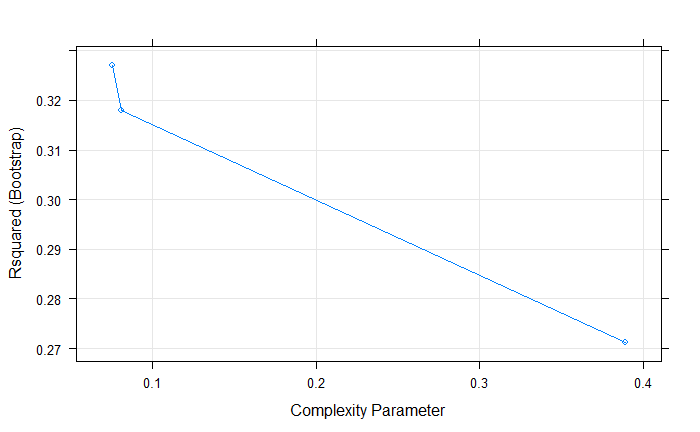

```r
plot(rpart.fit)
```

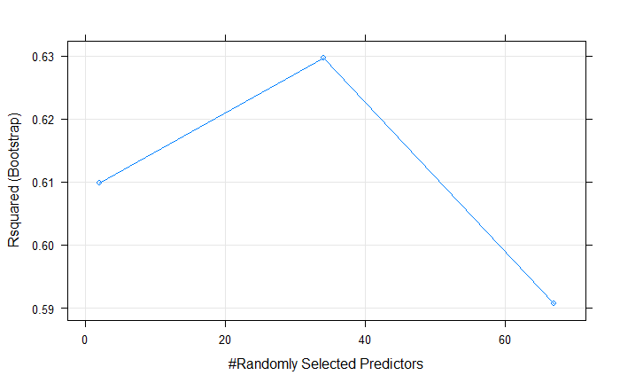

```r
rf.fit   <- train(data.set$train %>% dplyr::select(-Yield), data.set$train$Yield,
                  method = "rf",
                  metric = "Rsquared",
                  trControl = ctrl,
                  importance = TRUE)
plot(rf.fit)
```

[figure not shown]

```r
rf.fit$finalModel
```

```
Call:
 randomForest(x = x, y = y, mtry = param$mtry)
               Type of random forest: regression
                     Number of trees: 500
No. of variables tried at each split: 34

          Mean of squared residuals: 1.321701
                    % Var explained: 62.32
```

2. Which predictors are most important in the optimal tree-based regression model? Do either the biological or process variables dominate the list? How do the top 10 important predictors compare to the top 10 predictors from the optimal linear and nonlinear models?

```r
varImp(rf.fit, scale = FALSE)
```

```
rf variable importance

  only 20 most important variables shown (out of 67)

                                   Overall
ManufacturingProcess32              26.249
ManufacturingProcess17              10.362
BiologicalMaterial03                10.142
ManufacturingProcess13              10.045
BiologicalMaterial06                 7.542
BiologicalMaterial12                 6.386
ManufacturingProcess09               5.963
BiologicalMaterial11                 5.761
BiologicalMaterial02                 5.719
ManufacturingProcess31               5.354
ManufacturingProcess28               5.236
ManufacturingProcess18               5.129
ManufacturingProcess11               5.054
ManufacturingProcess33               4.879
ManufacturingProcess06               4.781
ManufacturingProcess30               4.723
BiologicalMaterial08                 4.512
ManufacturingProcess25               4.397
ManufacturingProcess18.boxcoxtrans   4.367
ManufacturingProcess19               4.340
```

> ManufacturingProcess32 is the most important followed by ManufacturingProcess17, BiologicalMaterial03, and ManufacturingProcess13 in that order. The Manufacturing Processes dominate the list and hold the highest importance compared to other variables.

> Random Forest does not natively allow for a plot of this type. I am assuming that the author envisioned another model making the being the best model as my model cannot be used in this way.

> Here is a plot of the tree and interestingly we see that the biological process 12 is the first split and then we our manufacturing nodes splitting the tree and the next level.

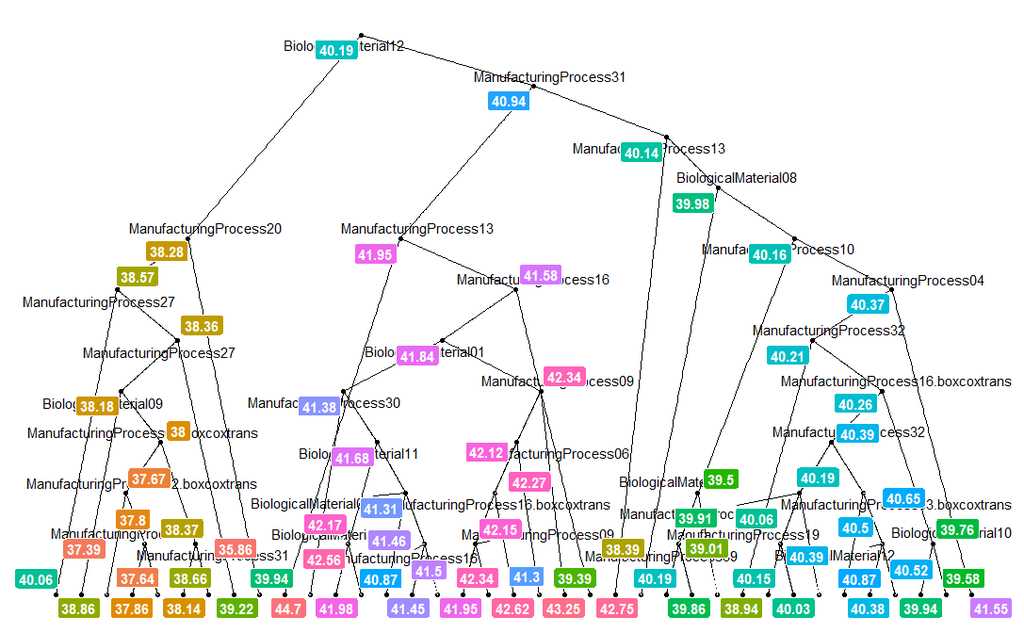

```r
#https://shiring.github.io/machine_learning/2017/03/16/rf_plot_ggraph
library(dplyr)
library(ggraph)
library(igraph)
tree_func <- function(final_model,
                      tree_num) {

  # get tree by index
  tree <- randomForest::getTree(final_model,
                                k = tree_num,
                                labelVar = TRUE) %>%
    tibble::rownames_to_column() %>%
    # make leaf split points to NA, so the 0s won't get plotted
    mutate(`split point` = ifelse(is.na(prediction), `split point`, NA))

  # prepare data frame for graph
  graph_frame <- data.frame(from = rep(tree$rowname, 2),
                            to = c(tree$`left daughter`, tree$`right daughter`))

  # convert to graph and delete the last node that we don't want to plot
  graph <- graph_from_data_frame(graph_frame) %>%
    delete_vertices("0")

  # set node labels
  V(graph)$node_label <- gsub("_", " ", as.character(tree$`split var`))
  V(graph)$leaf_label <- as.character(round(tree$prediction,2))
  V(graph)$split <- as.character(round(tree$`split point`, digits = 2))

  # plot
  plot <- ggraph(graph, 'dendrogram') +
    theme_bw() +
    geom_edge_link() +
    geom_node_point() +
    geom_node_text(aes(label = node_label), na.rm = TRUE, repel = TRUE) +
    geom_node_label(aes(label = split), vjust = 2.5, na.rm = TRUE, fill = "white") +
    geom_node_label(aes(label = leaf_label, fill = leaf_label), na.rm = TRUE,
                    repel = TRUE, colour = "white", fontface = "bold", show.legend = FALSE) +
    theme(panel.grid.minor = element_blank(),
          panel.grid.major = element_blank(),
          panel.background = element_blank(),
          plot.background = element_rect(fill = "white"),
          panel.border = element_blank(),
          axis.line = element_blank(),
          axis.text.x = element_blank(),
          axis.text.y = element_blank(),
          axis.ticks = element_blank(),
          axis.title.x = element_blank(),
          axis.title.y = element_blank(),
          plot.title = element_text(size = 18))

  print(plot)
}
tree_num <- max(which(rf.fit$finalModel$forest$ndbigtree == min(rf.fit$finalModel$forest$ndbigtree)))
tree_func(final_model = rf.fit$finalModel, tree_num = tree_num)
```